# Gene_Analysis

## Gene Expression Cancer RNA-Seq Analysis

## Problem Statement

### Context

RNA sequencing (RNAseq) is one of the most commonly used techniques in life sciences and has been widely used in cancer research, drug development, and cancer diagnosis and prognosis. Sequencing the coding regions or the whole cancer transcriptome can provide valuable information about gene expression changes in tumors. Cancer RNA-Seq enables the detection of strand-specific information, an important component of gene regulation. Cancer transcriptome sequencing captures both coding and non-coding RNA and provides strand orientation for a complete view of expression dynamics.

### Objective

To use the Principal Component Analysis (PCA) technique to transform a large set of variables into a smaller one that still contains most of the information in the large set

### Key Concepts

- Applying PCA for dimensionality reduction
- Visualizing the data in the lower dimension

### Data Description

This collection of data is part of the RNA-Seq (HiSeq) PANCAN data set, it is a random extraction of gene expressions of patients having different types of tumor:

- BRCA
- KIRC
- COAD
- LUAD
- PRAD

Samples (instances) are stored row-wise. Variables (attributes) of each sample are RNA-Seq gene expression levels measured by illumina HiSeq platform.

A dummy name (gene_X) is given to each attribute.

## Importing Libraries

```python
# to suppress warnings
import warnings
warnings.filterwarnings("ignore")

# Libraries for data management
import numpy as np
import pandas as pd

# Libraries for visualization
import matplotlib.pyplot as plt
import seaborn as sns
%matplotlib inline

# Libraries for data preprocessing
from scipy.stats import zscore
from sklearn.preprocessing import StandardScaler, MinMaxScaler

# Libraries for clustering
from scipy.spatial.distance import cdist, pdist
from sklearn.manifold import TSNE

# Libraries for PCA
from sklearn.decomposition import PCA
from numpy.linalg import eig

# Libraries for classification
from sklearn.tree import DecisionTreeClassifier
from sklearn.model_selection import train_test_split

# Setting the theme and fontsize of figures
sns.set_theme(style = 'darkgrid', font_scale = 1.13)

# Restricting the float value of a dataframe to 3 decimal points
pd.set_option('display.float_format', lambda x: '%.3f' % x)

# Mounting the drive
from google.colab import drive
drive.mount('/content/drive/')
```

## Loading the Dataset

```python
# Loading the datasets
data_samples = pd.read_csv('/content/drive/MyDrive/Python_files/gene_data.csv')
data_labels  = pd.read_csv('/content/drive/MyDrive/Python_files/gene_labels.csv')
# Ensuring the original datasets remain unchanged
df_samples = data_samples.copy()
df_labels  = data_labels.copy()
```

## Overview of the Dataset

Sanity checks and overall review of data

### Shape of Data

```python
print('The gene dataset consists of {} samples and {} features.'.format(df_samples.shape[0], df_samples.shape[1]))
print('The label dataset consists of {} samples and {} columns.'.format(df_labels.shape[0], df_labels.shape[1]))
```

```
The gene dataset consists of 801 samples and 20532 features.
The label dataset consists of 801 samples and 2 columns.
```

#### Notes:

- The gene (samples) dataset consists of gene expression levels of 801 samples, while the corresponding tumor type of each sample is stored in the label dataset. Both datasets include the same instances (samples).
- In the gene dataset, there are 20531 gene expression attributes and one column thant indexes the samples.

### Sample Rows

Checking the first and last few records

```python
# First 5 rows of gene expression dataset
df_samples.head()
```

|  | Unnamed: 0 | gene_0 | gene_1 | gene_2 | gene_3 | gene_4 | gene_5 | gene_6 | gene_7 | gene_8 | ... | gene_20521 | gene_20522 | gene_20523 | gene_20524 | gene_20525 | gene_20526 | gene_20527 | gene_20528 | gene_20529 | gene_20530 |
| --- | --- | --- | --- | --- | --- | --- | --- | --- | --- | --- | --- | --- | --- | --- | --- | --- | --- | --- | --- | --- | --- |
| 0 | sample_0 | 0.000 | 2.017 | 3.266 | 5.478 | 10.432 | 0.000 | 7.175 | 0.592 | 0.000 | ... | 4.927 | 8.210 | 9.724 | 7.220 | 9.120 | 12.003 | 9.651 | 8.921 | 5.287 | 0.000 |
| 1 | sample_1 | 0.000 | 0.593 | 1.588 | 7.586 | 9.623 | 0.000 | 6.816 | 0.000 | 0.000 | ... | 4.593 | 7.324 | 9.741 | 6.257 | 8.382 | 12.675 | 10.517 | 9.398 | 2.094 | 0.000 |
| 2 | sample_2 | 0.000 | 3.512 | 4.327 | 6.882 | 9.871 | 0.000 | 6.972 | 0.453 | 0.000 | ... | 5.125 | 8.127 | 10.909 | 5.402 | 9.912 | 9.045 | 9.788 | 10.090 | 1.683 | 0.000 |
| 3 | sample_3 | 0.000 | 3.664 | 4.508 | 6.659 | 10.196 | 0.000 | 7.843 | 0.435 | 0.000 | ... | 6.077 | 8.793 | 10.142 | 8.943 | 9.601 | 11.393 | 9.695 | 9.684 | 3.292 | 0.000 |
| 4 | sample_4 | 0.000 | 2.656 | 2.822 | 6.539 | 9.738 | 0.000 | 6.567 | 0.361 | 0.000 | ... | 5.996 | 8.891 | 10.374 | 7.181 | 9.847 | 11.922 | 9.218 | 9.461 | 5.110 | 0.000 |

5 rows × 20532 columns

```python
# Last 5 rows of gene expression dataset
df_labels.head()
```

|  | Unnamed: 0 | Class |
| --- | --- | --- |
| 0 | sample_0 | PRAD |
| 1 | sample_1 | LUAD |
| 2 | sample_2 | PRAD |
| 3 | sample_3 | PRAD |
| 4 | sample_4 | BRCA |

```python
# First 5 rows of label dataset
df_samples.tail()
```

|  | Unnamed: 0 | gene_0 | gene_1 | gene_2 | gene_3 | gene_4 | gene_5 | gene_6 | gene_7 | gene_8 | ... | gene_20521 | gene_20522 | gene_20523 | gene_20524 | gene_20525 | gene_20526 | gene_20527 | gene_20528 | gene_20529 | gene_20530 |
| --- | --- | --- | --- | --- | --- | --- | --- | --- | --- | --- | --- | --- | --- | --- | --- | --- | --- | --- | --- | --- | --- |
| 796 | sample_796 | 0.000 | 1.866 | 2.718 | 7.350 | 10.006 | 0.000 | 6.765 | 0.497 | 0.000 | ... | 6.088 | 9.118 | 10.005 | 4.484 | 9.615 | 12.031 | 9.813 | 10.093 | 8.819 | 0.000 |
| 797 | sample_797 | 0.000 | 3.943 | 4.454 | 6.347 | 10.057 | 0.000 | 7.320 | 0.000 | 0.000 | ... | 6.372 | 9.623 | 9.824 | 6.555 | 9.064 | 11.633 | 10.317 | 8.746 | 9.659 | 0.000 |
| 798 | sample_798 | 0.000 | 3.250 | 3.707 | 8.186 | 9.504 | 0.000 | 7.537 | 1.811 | 0.000 | ... | 5.719 | 8.611 | 10.486 | 3.590 | 9.351 | 12.181 | 10.681 | 9.467 | 4.677 | 0.587 |
| 799 | sample_799 | 0.000 | 2.590 | 2.788 | 7.319 | 9.987 | 0.000 | 9.213 | 0.000 | 0.000 | ... | 5.785 | 8.605 | 11.005 | 4.746 | 9.626 | 11.198 | 10.336 | 10.401 | 5.719 | 0.000 |
| 800 | sample_800 | 0.000 | 2.325 | 3.806 | 6.530 | 9.560 | 0.000 | 7.957 | 0.000 | 0.000 | ... | 6.403 | 8.594 | 10.243 | 9.139 | 10.103 | 11.641 | 10.607 | 9.845 | 4.551 | 0.000 |

5 rows × 20532 columns

```python
# Last 5 rows of label dataset
df_labels.tail()
```

|  | Unnamed: 0 | Class |
| --- | --- | --- |
| 796 | sample_796 | BRCA |
| 797 | sample_797 | LUAD |
| 798 | sample_798 | COAD |
| 799 | sample_799 | PRAD |
| 800 | sample_800 | PRAD |

#### Observations:

- As can be seen, both datasets contain the information about identical samples: one has the data with regard to RNA sequencing and the other includes the tumor kind of each sample.
- Some gene expression labels show a lot of variability, while some are zero most of the times.

### Dropping Zero Columns

Dropping all features whose values are all zero.

```python
# Counting the number of gene expression levels with only 0 as entry
print('Number of gene attributes for which all entries are zero:',
      (df_samples.iloc[:, 1:].max() - df_samples.iloc[:, 1:].min() == 0).sum())
# Looping over all numerical vars and dropping those with only zero entries
for col in df_samples.select_dtypes(include = np.number).columns.tolist():
    if(df_samples[col].max() - df_samples[col].min() == 0):
        df_samples.drop(columns = col, axis = 1, inplace = True)
print('The shape of the new gene dataset:', df_samples.shape)
```

```
Number of gene attributes for which all entries are zero: 267
The shape of the new gene dataset: (801, 20265)
```

### Merging the Datasets

```python
# Concatenating the samples and labels datasets
df = df_samples.copy()
df['Tumor Class'] = df_labels['Class']
# Renaming the column corresponding to sample indices
df.rename(columns = {'Unnamed: 0': 'Sample'}, inplace = True)
# Dropping 'sample' from the label of samples
for i in range(df.shape[0]):
    df.loc[i, 'Sample'] = str(i)
df.head()
```

|  | Sample | gene_0 | gene_1 | gene_2 | gene_3 | gene_4 | gene_6 | gene_7 | gene_8 | gene_9 | ... | gene_20522 | gene_20523 | gene_20524 | gene_20525 | gene_20526 | gene_20527 | gene_20528 | gene_20529 | gene_20530 | Tumor Class |
| --- | --- | --- | --- | --- | --- | --- | --- | --- | --- | --- | --- | --- | --- | --- | --- | --- | --- | --- | --- | --- | --- |
| 0 | 0 | 0.000 | 2.017 | 3.266 | 5.478 | 10.432 | 7.175 | 0.592 | 0.000 | 0.000 | ... | 8.210 | 9.724 | 7.220 | 9.120 | 12.003 | 9.651 | 8.921 | 5.287 | 0.000 | PRAD |
| 1 | 1 | 0.000 | 0.593 | 1.588 | 7.586 | 9.623 | 6.816 | 0.000 | 0.000 | 0.000 | ... | 7.324 | 9.741 | 6.257 | 8.382 | 12.675 | 10.517 | 9.398 | 2.094 | 0.000 | LUAD |
| 2 | 2 | 0.000 | 3.512 | 4.327 | 6.882 | 9.871 | 6.972 | 0.453 | 0.000 | 0.000 | ... | 8.127 | 10.909 | 5.402 | 9.912 | 9.045 | 9.788 | 10.090 | 1.683 | 0.000 | PRAD |
| 3 | 3 | 0.000 | 3.664 | 4.508 | 6.659 | 10.196 | 7.843 | 0.435 | 0.000 | 0.000 | ... | 8.793 | 10.142 | 8.943 | 9.601 | 11.393 | 9.695 | 9.684 | 3.292 | 0.000 | PRAD |
| 4 | 4 | 0.000 | 2.656 | 2.822 | 6.539 | 9.738 | 6.567 | 0.361 | 0.000 | 0.000 | ... | 8.891 | 10.374 | 7.181 | 9.847 | 11.922 | 9.218 | 9.461 | 5.110 | 0.000 | BRCA |

5 rows × 20266 columns

## EDA

```python
# Auxiliary function for annotating the bars in a countplot
def countplot_labeling(cntplt, data, perc = True, decimal = 1):
  ''' This function gets a countplot and the dataset that has generated
  the plot to produce the values corresponding to each bar (category).
  If perc = True, percentages will be shown.'''

  from math import isnan

  total = data.shape[0]  # total number of values in the dataset
  for p in cntplt.patches:
        height_val = float(p.get_height())
        if(isnan(height_val)):
          height_val = 0
        if(abs(height_val - round(height_val)) < 1e-6):
          height_val = int(height_val)
        if perc == True:
          # percentage of each category
          label = "{:.1f}%".format(100*height_val/total)
        else:
          label = "{}".format(round(height_val,decimal))  # count of each category
        x = p.get_x() + p.get_width()/2  # width of the plot
        y = p.get_height()  # height of the plot

        if(height_val == 0):
          label = '0'

        # annotate the bar
        cntplt.annotate(label, (x, y), ha = "center", va = "center", size = 12, xytext = (0, 5), textcoords = "offset points")
```

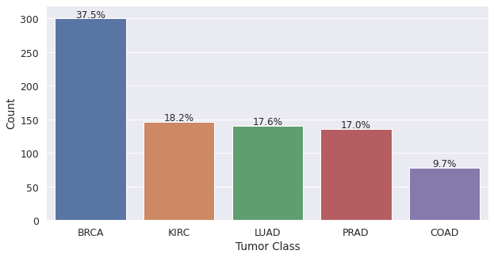

```python
# Plotting the frequency distribution of tumor classes
plt.figure(figsize = (10, 5));
cntplt = sns.countplot(data = df, x = 'Tumor Class', order = df['Tumor Class'].value_counts().index);
countplot_labeling(cntplt, df);
plt.ylabel('Count');
plt.ylim(0, 320);
```

#### Observations:

BRCA and COAD are the most and the least frequent tumor classes, respectively.

## Data Preprocessing

Normalization (sacling) of numerical features

```python
# Dataset being used for reduced-order modeling including only the numerical attributes
df_rom = df.drop(columns = ['Sample', 'Tumor Class'], axis = 1)
# Scaling the data
df_rom_scaled = df_rom.apply(zscore)
df_rom_scaled.head()
```

|  | gene_0 | gene_1 | gene_2 | gene_3 | gene_4 | gene_6 | gene_7 | gene_8 | gene_9 | gene_10 | ... | gene_20521 | gene_20522 | gene_20523 | gene_20524 | gene_20525 | gene_20526 | gene_20527 | gene_20528 | gene_20529 | gene_20530 |
| --- | --- | --- | --- | --- | --- | --- | --- | --- | --- | --- | --- | --- | --- | --- | --- | --- | --- | --- | --- | --- | --- |
| 0 | -0.195 | -0.828 | 0.160 | -1.948 | 1.222 | -0.208 | 0.181 | -0.125 | -0.066 | -0.082 | ... | -1.300 | -0.922 | -0.878 | 0.996 | -1.166 | 0.389 | -0.870 | -1.188 | -0.116 | -0.262 |
| 1 | -0.195 | -2.015 | -1.415 | 1.353 | -0.377 | -0.532 | -0.983 | -0.125 | -0.066 | -0.587 | ... | -1.747 | -2.392 | -0.832 | 0.592 | -2.550 | 1.392 | 0.624 | -0.342 | -1.657 | -0.262 |
| 2 | -0.195 | 0.417 | 1.157 | 0.250 | 0.113 | -0.391 | -0.093 | -0.125 | -0.066 | -0.587 | ... | -1.034 | -1.060 | 2.249 | 0.233 | 0.318 | -4.026 | -0.632 | 0.887 | -1.855 | -0.262 |
| 3 | -0.195 | 0.544 | 1.326 | -0.099 | 0.756 | 0.395 | -0.128 | -0.125 | -0.066 | -0.587 | ... | 0.241 | 0.045 | 0.225 | 1.720 | -0.264 | -0.522 | -0.794 | 0.166 | -1.079 | -0.262 |
| 4 | -0.195 | -0.296 | -0.257 | -0.286 | -0.149 | -0.757 | -0.273 | -0.125 | -0.066 | -0.587 | ... | 0.133 | 0.208 | 0.838 | 0.980 | 0.197 | 0.269 | -1.616 | -0.230 | -0.202 | -0.262 |

5 rows × 20264 columns

## Applying PCA

### Finding the Required Number of PCA Components

Here, we find out how many features need to be extracted to explain at least 80% of the total variance.

```python
# Calculating PCA components and eigenvalues using covariance matrix
pca_scheme = PCA(n_components = min(df_rom.shape[0], df_rom.shape[1]), svd_solver = 'full')
pca_gene = pca_scheme.fit_transform(df_rom_scaled)

# Looping over eigenvalues to find out how many of them explain 80% of variance
for i in range(df_rom.shape[0]):
    if(pca_scheme.explained_variance_ratio_[0:i+1].sum() >= 0.8):
      r = i+1
      break
print('The dimension of the ROM, found using Python\'s PCA, explaining 80% of the variance is {}.'.format(r))
```

```
The dimension of the ROM, found using Python's PCA, explaining 80% of the variance is 183.
```

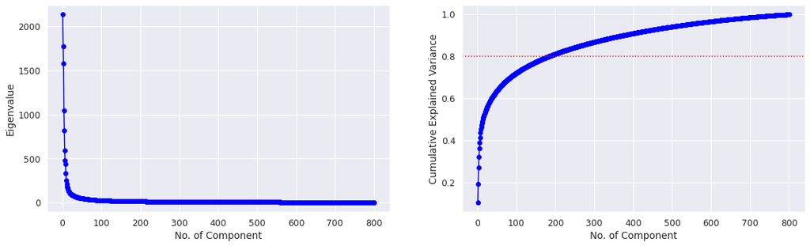

```python
# Plotting decay of eigenvalues and cumulative explained variance
plt.figure(figsize = (16, 5));
plt.subplot(121);
plt.plot(np.arange(1, df.shape[0]+1), pca_scheme.explained_variance_,
         color = 'blue', marker = 'o');
plt.xlabel('No. of Component');
plt.ylabel('Eigenvalue');
plt.subplot(122);
plt.plot(np.arange(1, df.shape[0]+1), pca_scheme.explained_variance_ratio_.cumsum(),
         color = 'blue', marker = 'o');
plt.axhline(0.8, color = 'red', linestyle = ':');
plt.xlabel('No. of Component');
plt.ylabel('Cumulative Explained Variance');
plt.tight_layout(w_pad = 4);
```

#### Observations:

The original problem isn't very low-dimensional and requires more than 180 PCA components to explain 80% of the variance.

### Projecting the Data to the Coordinates of Extracted Features

Here, we transform the original data into the coordinate system constructed by the natural axes (retained eigenvectors of the covariance matrix) and build a low-order representation of it.

```python
# Applying dimensionality reduction on the original data using
# n_component = r so that 80% of variance is explained
final_pca_model = PCA(n_components = r, svd_solver = 'full')
reduced_df = pd.DataFrame(final_pca_model.fit_transform(df_rom_scaled))
# Renaming the columns of reduced dataset (C: component)
for i, col in enumerate(reduced_df.columns.tolist()):
    reduced_df.rename(columns = {col: 'C'+str(i+1)}, inplace = True)
reduced_df['Tumor Class'] = df['Tumor Class']
reduced_df.head()
```

|  | C1 | C2 | C3 | C4 | C5 | C6 | C7 | C8 | C9 | C10 | ... | C175 | C176 | C177 | C178 | C179 | C180 | C181 | C182 | C183 | Tumor Class |
| --- | --- | --- | --- | --- | --- | --- | --- | --- | --- | --- | --- | --- | --- | --- | --- | --- | --- | --- | --- | --- | --- |
| 0 | -57.447 | 95.411 | 74.302 | -12.167 | 7.982 | 36.158 | -7.669 | 19.951 | 0.142 | 3.035 | ... | -3.426 | -3.554 | 2.602 | 5.896 | -0.908 | 9.060 | -3.528 | -3.221 | 4.024 | PRAD |
| 1 | -16.919 | 0.732 | -64.073 | -2.095 | -25.426 | 27.784 | -16.133 | -17.031 | -22.024 | -27.923 | ... | 5.591 | -2.262 | -1.415 | -1.283 | 2.892 | 0.280 | -3.224 | 2.275 | -0.252 | LUAD |
| 2 | -70.345 | -19.303 | 20.488 | 48.103 | 24.438 | 17.463 | 20.707 | -47.627 | -28.648 | -12.785 | ... | -2.637 | 6.090 | -4.091 | 10.278 | -8.018 | 1.712 | -10.784 | -11.153 | -2.665 | PRAD |
| 3 | -49.162 | -9.228 | 61.244 | 37.806 | 1.039 | 23.240 | -4.801 | -21.555 | -15.375 | -12.882 | ... | -1.121 | -0.081 | -1.166 | 0.887 | -0.025 | 5.831 | -1.113 | -0.431 | 0.093 | PRAD |
| 4 | -18.133 | -51.328 | 16.598 | -17.699 | 26.389 | -1.552 | -6.266 | 12.337 | -4.234 | 28.804 | ... | 1.854 | -0.323 | 1.235 | 6.195 | -2.393 | -3.220 | -5.038 | -0.691 | -4.202 | BRCA |

5 rows × 184 columns

### Demonstration of Tumor Classes in Lower Dimension

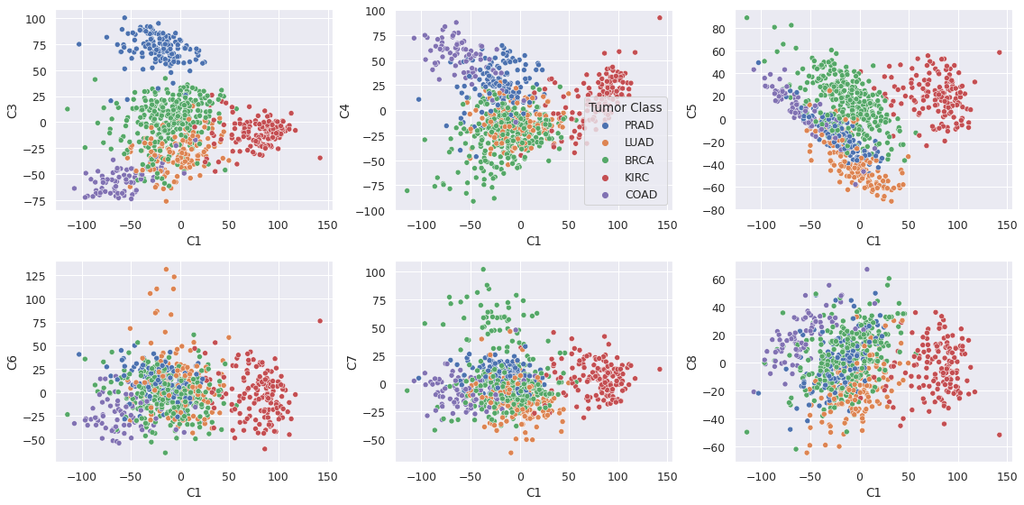

```python
# Plotting PC component one vs. components 2 to 6
plt.figure(figsize = (16, 8));
for i in np.arange(1, 7):
    plt.subplot(2, 3, i);
    sns.scatterplot(data = reduced_df, x = 'C1', y = reduced_df.columns.tolist()[i+1],
                    hue = 'Tumor Class');
    if(i != 2):
        plt.legend().set_visible(False);
plt.tight_layout(w_pad = 0);
```

## Applying t-SNE

Here, we develop a low-dimensional (2D) representation of the original data via *t-distributed Stochastic Neighbor Embedding*, solely for the purpose of visualizing tumor types in a separate fashion.

### Using Default Hyperparameters

```python
# Implementing t-SNE-based reduced-order modeling to visualize the distinct clusters of data in 2D
tsne_model = TSNE(n_components = 2, random_state = 1)
df_tsne_clust = pd.DataFrame(tsne_model.fit_transform(df_rom_scaled),
                             columns = ['C1', 'C2'])
df_tsne_clust['Tumor Class'] = df['Tumor Class']
df_tsne_clust.head()
```

|  | C1 | C2 | Tumor Class |
| --- | --- | --- | --- |
| 0 | 4.365 | 27.364 | PRAD |
| 1 | 15.797 | -3.434 | LUAD |
| 2 | 12.053 | 38.397 | PRAD |
| 3 | 14.623 | 35.074 | PRAD |
| 4 | -15.710 | 4.417 | BRCA |

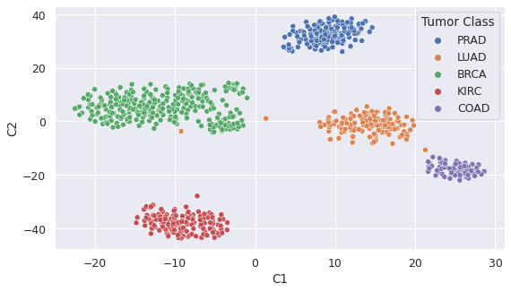

```python
# Plotting the low-dimensional representation of the data provided by t-SNE
plt.figure(figsize = (9, 5));
sns.scatterplot(data = df_tsne_clust, x = 'C1', y = 'C2', hue = 'Tumor Class');
```

#### Observations:

t-SNE has almost perfectly sifted data points based on their tumor class. There are a few mixed points, which might be fixed by altering perplexity.

### Studying the Effect of Perplexity

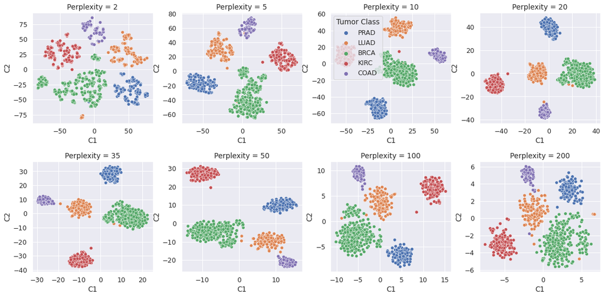

```python
# Listing a wide range of perplexity levels
perplex_levels = [2, 5, 10, 20, 35, 50, 100, 200]
plt.figure(figsize = (16, 8));
for i, perplex_level in enumerate(perplex_levels):
    # Implementing t-SNE-based clustering
    tsne_model = TSNE(n_components = 2, perplexity = perplex_level, random_state = 1)
    df_tsne = pd.DataFrame(tsne_model.fit_transform(df_rom_scaled),
                             columns = ['C1', 'C2'])
    df_tsne['Tumor Class'] = df['Tumor Class']
    # Low-dimensional representation of data points rendered by t-SNE
    plt.subplot(2, 4, i+1);
    sns.scatterplot(data = df_tsne, x = 'C1', y = 'C2', hue = 'Tumor Class');
    plt.title('Perplexity = {}'.format(perplex_level))
    if(i != 2):
        plt.legend().set_visible(False);
plt.tight_layout(w_pad = 0);
```